# Analysis module 5: final machine-learning and multivariate models

[figure not shown]

[figure not shown]

[figure not shown]

[figure not shown]

Modular Random Forests

Regression: sero

Regression: dose 1 shedding

Regression: neonatal RV

Regression: RV-IgA

Multivariate regressions

Session info

# Modular Random Forests

#### India (all)

##### IND (full)

Number of infants with complete data: 249  
Number who seroconverted: 64; number who did not: 185 Number who shed dose 1: 72 ; number who did not: 177

##### IND (neo+)

Number of infants with complete data: 133  
Number who seroconverted: 38; number who did not: 95 Number who shed dose 1: 25 ; number who did not: 108

##### IND (neo-)

Number of infants with complete data: 116  
Number who seroconverted: 26; number who did not: 90 Number who shed dose 1: 47 ; number who did not: 69

#### Model accuracy

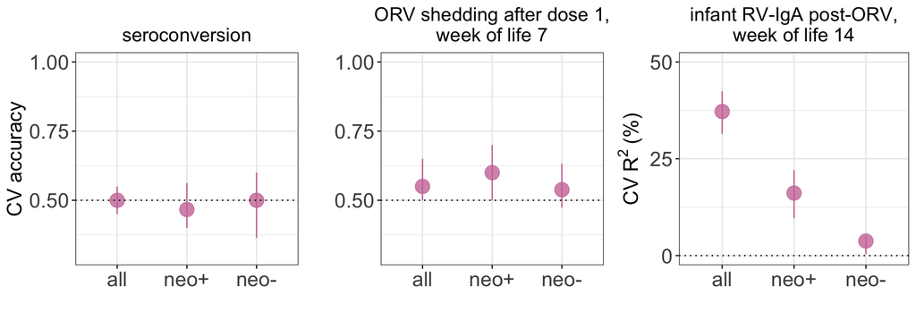

#### Importance - infant RV-IgA post-ORV

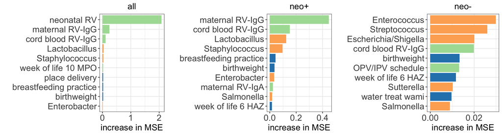

#### Importance - seroconversion

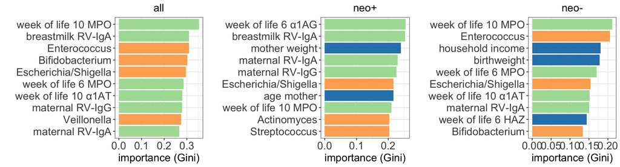

#### Importance - dose 1 shedding

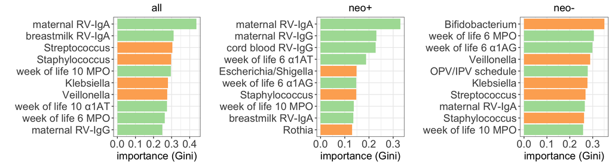

# Regression: sero

### India (full)

#### Baseline variables

| variable | n total (r) | responders | non-responders | RR (95% CI) | p |
| --- | --- | --- | --- | --- | --- |
| sex_baby (female) | 305 (85) | 41/85 (48.2%) | 109/220 (49.5%) | 0.96 (0.65-1.35) | 0.83742 |
| mode_delivery (caesarean) | 305 (85) | 22/85 (25.9%) | 48/220 (21.8%) | 1.17 (0.75-1.67) | 0.44971 |
| place_delivery (tertiary) | 305 (85) | 37/85 (43.5%) | 92/220 (41.8%) | 1.05 (0.71-1.47) | 0.78624 |
| breastfed_child (exclusive) | 305 (85) | 79/85 (92.9%) | 185/220 (84.1%) | 2.04 (1.07-3.68) | 0.04814 |
| age_at_first_dose | 305 (85) | 42.8 (1.8) | 42.5 (1.1) | 1.09 (0.96-1.23) | 0.19185 |
| birth_weight | 305 (85) | 3.0 (0.4) | 3.0 (0.4) | 1.03 (0.65-1.51) | 0.90240 |
| HIV_status | 297 (83) | NA | NA | NA | NA |
| HAZ_6_8w | 304 (84) | -0.4 (1.1) | -0.5 (1.1) | 1.08 (0.91-1.27) | 0.35963 |
| antibiotic_exposure (yes) | 305 (85) | 24/85 (28.2%) | 60/220 (27.3%) | 1.04 (0.67-1.48) | 0.86602 |
| age_mother | 305 (85) | 23.9 (3.7) | 23.3 (3.7) | 1.03 (0.98-1.08) | 0.19047 |
| mother_weight | 305 (85) | 61.7 (9.5) | 60.9 (11.0) | 1.00 (0.99-1.02) | 0.57724 |
| parity | 305 (85) | 0.8 (0.9) | 0.9 (0.9) | 0.95 (0.76-1.15) | 0.59651 |
| maternal_education | 305 (85) | 10.1 (3.9) | 9.8 (3.6) | 1.02 (0.97-1.07) | 0.52819 |
| type_house (pucca) | 305 (85) | 60/85 (70.6%) | 139/220 (63.2%) | 1.28 (0.86-1.82) | 0.22432 |
| water_treat_wami (yes) | 288 (77) | 35/77 (45.5%) | 96/211 (45.5%) | 1.00 (0.66-1.42) | 0.99481 |
| sanitation (yes) | 305 (85) | 36/85 (42.4%) | 101/220 (45.9%) | 0.90 (0.60-1.27) | 0.57575 |
| kitchen (yes) | 305 (85) | 58/85 (68.2%) | 150/220 (68.2%) | 1.00 (0.67-1.44) | 0.99283 |
| refrigerator (yes) | 305 (85) | 54/85 (63.5%) | 119/220 (54.1%) | 1.33 (0.91-1.85) | 0.13685 |
| crowding_wami (over_4) | 305 (85) | 41/85 (48.2%) | 107/220 (48.6%) | 0.99 (0.67-1.38) | 0.94990 |
| household_income | 305 (85) | 7396.9 (6565.2-8334.1) | 8011.5 (7390.1-8685.1) | 0.84 (0.59-1.15) | 0.29239 |
| A1AT_BS3_Concugml | 300 (83) | 704.8 (601.1-826.3) | 745.0 (676.3-820.6) | 0.92 (0.70-1.19) | 0.55213 |
| A1AT_BS5_Concugml | 297 (83) | 849.3 (713.5-1011.1) | 807.7 (715.4-912.0) | 1.05 (0.85-1.29) | 0.65599 |
| MPO_BS3_Concngml | 300 (83) | 5696.6 (4057.7-7997.5) | 6729.5 (5510.4-8218.5) | 0.95 (0.83-1.07) | 0.39215 |
| MPO_BS5_Concngml | 297 (83) | 6408.8 (4680.5-8775.3) | 7777.5 (6365.3-9502.9) | 0.94 (0.82-1.06) | 0.30973 |
| AG_Concugml | 304 (84) | 696.2 (662.6-731.4) | 733.3 (708.7-758.7) | 0.50 (0.19-1.12) | 0.10537 |
| MB1_IgA | 305 (85) | 126.2 (102.3-155.7) | 137.2 (119.7-157.2) | 0.94 (0.78-1.12) | 0.51766 |
| BM1_IgA | 301 (83) | 25.5 (19.8-32.8) | 25.2 (21.3-29.8) | 1.01 (0.86-1.16) | 0.93342 |
| MB1_IgG | 305 (85) | 10680.8 (8892.2-12829.2) | 9795.4 (8531.3-11246.9) | 1.07 (0.89-1.27) | 0.49334 |
| CB1_IgG | 305 (85) | 15258.4 (12758.2-18248.6) | 13399.9 (11659.4-15400.2) | 1.10 (0.92-1.33) | 0.30561 |
| BB1_IgG | 305 (85) | 6639.7 (5503.1-8011.1) | 7916.2 (6932.5-9039.5) | 0.87 (0.71-1.05) | 0.15507 |
| Shannon_1w | 287 (79) | 1.2 (0.4) | 1.3 (0.4) | 0.74 (0.41-1.22) | 0.26719 |
| Shannon_4w | 285 (76) | 1.1 (0.4) | 1.3 (0.4) | 0.49 (0.27-0.83) | 0.00763 |
| Shannon_6w | 287 (79) | 1.2 (0.4) | 1.3 (0.4) | 0.52 (0.28-0.90) | 0.01867 |
| Shannon_10w | 281 (79) | 1.3 (0.3) | 1.4 (0.3) | 0.79 (0.41-1.38) | 0.44357 |
| pre_exposed (yes) | 304 (85) | 51/85 (60.0%) | 115/219 (52.5%) | 1.25 (0.86-1.73) | 0.23994 |

#### Polio vaccine schedule

| levels | responders | nonresponders | rr | p |
| --- | --- | --- | --- | --- |
| bOPV_only | 36/85 (42.4%) | 58/220 (26.4%) | ref | ref |
| IPV | 25/85 (29.4%) | 74/220 (33.6%) | 0.66 (0.40-1.00) | 0.053 |
| tOPV_bOPV | 12/85 (14.1%) | 44/220 (20.0%) | 0.56 (0.29-0.95) | 0.034 |
| tOPV_only | 12/85 (14.1%) | 44/220 (20.0%) | 0.56 (0.29-0.95) | 0.034 |

#### Likelihood ratio test

```
Analysis of Deviance Table

Model 1: outcome ~ OPV_IPV
Model 2: outcome ~ 1
  Resid. Df Resid. Dev Df Deviance Pr(>Chi)
1       301     353.39
2       304     360.94 -3  -7.5545  0.05617 .
---
Signif. codes:  0 '***' 0.001 '**' 0.01 '*' 0.05 '.' 0.1 ' ' 1
```

### India (neo+)

#### Baseline variables

| variable | n total (r) | responders | non-responders | RR (95% CI) | p |
| --- | --- | --- | --- | --- | --- |
| sex_baby (female) | 166 (51) | 24/51 (47.1%) | 61/115 (53.0%) | 0.85 (0.50-1.30) | 0.47705 |
| mode_delivery (caesarean) | 166 (51) | 12/51 (23.5%) | 34/115 (29.6%) | 0.80 (0.42-1.31) | 0.42375 |
| place_delivery (tertiary) | 166 (51) | 26/51 (51.0%) | 72/115 (62.6%) | 0.72 (0.42-1.12) | 0.16131 |
| breastfed_child (exclusive) | 166 (51) | 48/51 (94.1%) | 97/115 (84.3%) | 2.32 (0.95-4.80) | 0.09312 |
| age_at_first_dose | 166 (51) | 42.8 (2.2) | 42.5 (1.0) | 1.09 (0.94-1.28) | 0.24040 |
| birth_weight | 166 (51) | 2.9 (0.4) | 3.0 (0.4) | 0.80 (0.40-1.38) | 0.45074 |
| HIV_status | 163 (50) | NA | NA | NA | NA |
| HAZ_6_8w | 166 (51) | -0.4 (1.2) | -0.5 (1.0) | 1.02 (0.82-1.25) | 0.82604 |
| antibiotic_exposure (yes) | 166 (51) | 14/51 (27.5%) | 34/115 (29.6%) | 0.93 (0.52-1.46) | 0.78168 |
| age_mother | 166 (51) | 24.2 (3.9) | 23.2 (3.7) | 1.05 (0.99-1.12) | 0.10620 |
| mother_weight | 166 (51) | 62.4 (10.4) | 60.4 (10.8) | 1.01 (0.99-1.03) | 0.25705 |
| parity | 166 (51) | 0.8 (0.9) | 0.8 (0.9) | 0.98 (0.74-1.25) | 0.90528 |
| maternal_education | 166 (51) | 10.1 (4.1) | 9.9 (3.5) | 1.01 (0.95-1.08) | 0.73875 |
| type_house (pucca) | 166 (51) | 37/51 (72.5%) | 83/115 (72.2%) | 1.01 (0.58-1.60) | 0.96027 |
| water_treat_wami (yes) | 157 (46) | 18/46 (39.1%) | 60/111 (54.1%) | 0.65 (0.36-1.06) | 0.09060 |
| sanitation (yes) | 166 (51) | 24/51 (47.1%) | 53/115 (46.1%) | 1.03 (0.62-1.54) | 0.90778 |
| kitchen (yes) | 166 (51) | 36/51 (70.6%) | 82/115 (71.3%) | 0.98 (0.57-1.54) | 0.92520 |
| refrigerator (yes) | 166 (51) | 35/51 (68.6%) | 68/115 (59.1%) | 1.34 (0.81-2.02) | 0.24614 |
| crowding_wami (over_4) | 166 (51) | 24/51 (47.1%) | 55/115 (47.8%) | 0.98 (0.59-1.48) | 0.92724 |
| household_income | 166 (51) | 8186.9 (7156.0-9366.2) | 8085.1 (7216.6-9058.0) | 1.03 (0.67-1.47) | 0.89680 |
| A1AT_BS3_Concugml | 163 (50) | 689.1 (559.7-848.3) | 724.6 (635.0-826.8) | 0.93 (0.65-1.27) | 0.67736 |
| A1AT_BS5_Concugml | 162 (50) | 804.3 (646.8-1000.2) | 756.4 (627.6-911.7) | 1.05 (0.81-1.34) | 0.69724 |
| MPO_BS3_Concngml | 163 (50) | 6142.9 (3949.2-9555.2) | 6465.3 (4897.7-8534.5) | 0.98 (0.84-1.14) | 0.84099 |
| MPO_BS5_Concngml | 162 (50) | 6153.8 (3966.5-9547.3) | 6825.2 (5160.8-9026.5) | 0.97 (0.82-1.13) | 0.68506 |
| AG_Concugml | 165 (50) | 680.7 (639.5-724.5) | 728.8 (694.6-764.6) | 0.40 (0.10-1.16) | 0.10870 |
| MB1_IgA | 166 (51) | 115.9 (90.0-149.2) | 138.4 (115.5-165.8) | 0.87 (0.66-1.11) | 0.26983 |
| BM1_IgA | 163 (50) | 26.6 (18.8-37.6) | 22.5 (18.0-27.9) | 1.08 (0.89-1.29) | 0.40011 |
| MB1_IgG | 166 (51) | 11283.4 (9126.6-13949.9) | 8992.8 (7403.5-10923.2) | 1.18 (0.93-1.47) | 0.16752 |
| CB1_IgG | 166 (51) | 15815.2 (12820.8-19509.1) | 12581.0 (10551.0-15001.6) | 1.22 (0.95-1.54) | 0.13170 |
| BB1_IgG | 166 (51) | 7589.2 (6134.0-9389.6) | 10383.6 (8872.4-12152.1) | 0.71 (0.50-0.96) | 0.02734 |
| Shannon_1w | 155 (47) | 1.3 (0.4) | 1.3 (0.4) | 1.12 (0.59-1.82) | 0.69028 |
| Shannon_4w | 156 (46) | 1.2 (0.4) | 1.3 (0.4) | 0.69 (0.33-1.25) | 0.24270 |
| Shannon_6w | 154 (46) | 1.2 (0.4) | 1.3 (0.4) | 0.67 (0.30-1.28) | 0.25671 |
| Shannon_10w | 160 (49) | 1.3 (0.3) | 1.4 (0.3) | 0.67 (0.27-1.37) | 0.31595 |

#### Polio vaccine schedule

| levels | responders | nonresponders | rr | p |
| --- | --- | --- | --- | --- |
| bOPV_only | 24/51 (47.1%) | 33/115 (28.7%) | ref | ref |
| IPV | 11/51 (21.6%) | 36/115 (31.3%) | 0.56 (0.27-0.98) | 0.047 |
| tOPV_bOPV | 7/51 (13.7%) | 22/115 (19.1%) | 0.57 (0.24-1.08) | 0.105 |
| tOPV_only | 9/51 (17.6%) | 24/115 (20.9%) | 0.65 (0.30-1.14) | 0.162 |

#### Likelihood ratio test

```
Analysis of Deviance Table

Model 1: outcome ~ OPV_IPV
Model 2: outcome ~ 1
  Resid. Df Resid. Dev Df Deviance Pr(>Chi)
1       162     199.47
2       165     204.80 -3  -5.3333    0.149
```

### India (neo-)

#### Baseline variables

| variable | n total (r) | responders | non-responders | RR (95% CI) | p |
| --- | --- | --- | --- | --- | --- |
| sex_baby (female) | 138 (34) | 17/34 (50.0%) | 47/104 (45.2%) | 1.16 (0.62-1.92) | 0.62578 |
| mode_delivery (caesarean) | 138 (34) | 10/34 (29.4%) | 13/104 (12.5%) | 2.08 (1.09-3.18) | 0.02548 |
| place_delivery (tertiary) | 138 (34) | 11/34 (32.4%) | 19/104 (18.3%) | 1.72 (0.90-2.72) | 0.08801 |
| breastfed_child (exclusive) | 138 (34) | 31/34 (91.2%) | 87/104 (83.7%) | 1.75 (0.66-4.10) | 0.28720 |
| age_at_first_dose | 138 (34) | 42.7 (1.1) | 42.6 (1.2) | 1.08 (0.83-1.34) | 0.53951 |
| birth_weight | 138 (34) | 3.0 (0.3) | 2.9 (0.5) | 1.41 (0.74-2.31) | 0.27768 |
| HIV_status | 133 (33) | NA | NA | NA | NA |
| HAZ_6_8w | 137 (33) | -0.3 (1.0) | -0.5 (1.1) | 1.17 (0.90-1.50) | 0.24678 |
| antibiotic_exposure (yes) | 138 (34) | 10/34 (29.4%) | 26/104 (25.0%) | 1.18 (0.58-2.01) | 0.61145 |
| age_mother | 138 (34) | 23.4 (3.5) | 23.4 (3.8) | 1.00 (0.92-1.08) | 0.98013 |
| mother_weight | 138 (34) | 60.6 (7.9) | 61.4 (11.2) | 0.99 (0.96-1.02) | 0.68790 |
| parity | 138 (34) | 0.9 (0.9) | 1.0 (0.9) | 0.91 (0.63-1.25) | 0.58032 |
| maternal_education | 138 (34) | 10.1 (3.8) | 9.7 (3.6) | 1.03 (0.95-1.11) | 0.52917 |
| type_house (pucca) | 138 (34) | 23/34 (67.6%) | 55/104 (52.9%) | 1.61 (0.86-2.69) | 0.13472 |
| water_treat_wami (yes) | 130 (31) | 17/31 (54.8%) | 36/99 (36.4%) | 1.76 (0.95-2.86) | 0.07068 |
| sanitation (yes) | 138 (34) | 12/34 (35.3%) | 47/104 (45.2%) | 0.73 (0.36-1.29) | 0.31280 |
| kitchen (yes) | 138 (34) | 22/34 (64.7%) | 67/104 (64.4%) | 1.01 (0.53-1.76) | 0.97613 |
| refrigerator (yes) | 138 (34) | 19/34 (55.9%) | 50/104 (48.1%) | 1.27 (0.68-2.10) | 0.43024 |
| crowding_wami (over_4) | 138 (34) | 17/34 (50.0%) | 51/104 (49.0%) | 1.03 (0.55-1.73) | 0.92245 |
| household_income | 138 (34) | 6352.6 (5106.2-7903.3) | 7914.0 (7036.3-8901.2) | 0.59 (0.30-1.02) | 0.07237 |
| A1AT_BS3_Concugml | 136 (33) | 729.2 (562.0-946.3) | 763.5 (660.5-882.5) | 0.94 (0.60-1.38) | 0.75501 |
| A1AT_BS5_Concugml | 134 (33) | 922.4 (682.6-1246.4) | 864.2 (740.4-1008.7) | 1.08 (0.74-1.53) | 0.68271 |
| MPO_BS3_Concngml | 136 (33) | 5081.4 (2912.7-8864.7) | 7007.0 (5215.0-9414.7) | 0.90 (0.72-1.09) | 0.29253 |
| MPO_BS5_Concngml | 134 (33) | 6815.4 (4325.0-10739.6) | 9193.9 (6889.2-12269.7) | 0.89 (0.71-1.10) | 0.29343 |
| AG_Concugml | 138 (34) | 719.5 (662.0-782.0) | 737.8 (702.2-775.2) | 0.72 (0.17-2.05) | 0.61046 |
| MB1_IgA | 138 (34) | 143.4 (98.3-209.1) | 136.2 (110.2-168.2) | 1.03 (0.78-1.34) | 0.80922 |
| BM1_IgA | 137 (33) | 24.0 (16.4-35.0) | 28.9 (22.2-37.6) | 0.91 (0.70-1.15) | 0.47175 |
| MB1_IgG | 138 (34) | 9836.7 (6983.2-13856.2) | 10693.6 (8759.9-13054.2) | 0.94 (0.69-1.25) | 0.67521 |
| CB1_IgG | 138 (34) | 14459.7 (10378.8-20145.4) | 14219.8 (11384.3-17761.4) | 1.01 (0.77-1.33) | 0.93816 |
| BB1_IgG | 138 (34) | 5433.5 (3838.6-7691.1) | 5853.4 (4754.4-7206.6) | 0.95 (0.71-1.25) | 0.71846 |
| Shannon_1w | 131 (32) | 1.1 (0.4) | 1.3 (0.3) | 0.31 (0.10-0.82) | 0.01923 |
| Shannon_4w | 128 (30) | 1.0 (0.4) | 1.2 (0.4) | 0.25 (0.08-0.64) | 0.00430 |
| Shannon_6w | 132 (33) | 1.1 (0.4) | 1.3 (0.4) | 0.37 (0.13-0.87) | 0.02406 |
| Shannon_10w | 120 (30) | 1.4 (0.3) | 1.4 (0.3) | 1.00 (0.35-2.17) | 0.99722 |

#### Polio vaccine schedule

| levels | responders | nonresponders | rr | p |
| --- | --- | --- | --- | --- |
| bOPV_only | 12/34 (35.3%) | 25/104 (24.0%) | ref | ref |
| IPV | 14/34 (41.2%) | 37/104 (35.6%) | 0.85 (0.40-1.51) | 0.613 |
| tOPV_bOPV | 5/34 (14.7%) | 22/104 (21.2%) | 0.57 (0.19-1.29) | 0.218 |
| tOPV_only | 3/34 ( 8.8%) | 20/104 (19.2%) | 0.40 (0.09-1.09) | 0.102 |

#### Likelihood ratio test

```
Analysis of Deviance Table

Model 1: outcome ~ OPV_IPV
Model 2: outcome ~ 1
  Resid. Df Resid. Dev Df Deviance Pr(>Chi)
1       134     150.26
2       137     154.10 -3  -3.8384   0.2794
```

### Malawi

#### Baseline variables

| variable | n total (r) | responders | non-responders | RR (95% CI) | p |
| --- | --- | --- | --- | --- | --- |
| sex_baby (female) | 103 (24) | 14/24 (58.3%) | 39/79 (49.4%) | 1.32 (0.63-2.40) | 0.44264 |
| mode_delivery | 103 (24) | NA | NA | NA | NA |
| place_delivery | 0 (0) | NA | NA | NA | NA |
| breastfed_child (exclusive) | 103 (24) | 20/24 (83.3%) | 73/79 (92.4%) | 0.54 (0.17-1.34) | 0.19947 |
| age_at_first_dose | 103 (24) | 42.1 (0.5) | 42.0 (0.7) | 1.14 (0.67-2.04) | 0.65516 |
| birth_weight | 103 (24) | 3.0 (0.3) | 3.0 (0.5) | 0.66 (0.24-1.50) | 0.35832 |
| HIV_status (positive) | 100 (23) | 5/23 (21.7%) | 16/77 (20.8%) | 1.04 (0.37-2.11) | 0.92100 |
| HAZ_6_8w | 103 (24) | -2.5 (1.0) | -2.5 (1.3) | 1.01 (0.73-1.32) | 0.96384 |
| antibiotic_exposure (yes) | 103 (24) | 7/24 (29.2%) | 20/79 (25.3%) | 1.16 (0.48-2.17) | 0.70746 |
| age_mother | 103 (24) | 26.6 (4.0) | 25.9 (6.0) | 1.02 (0.95-1.08) | 0.58851 |
| mother_weight | 0 (0) | NA | NA | NA | NA |
| parity | 0 (0) | NA | NA | NA | NA |
| maternal_education | 0 (0) | NA | NA | NA | NA |
| type_house | 0 (0) | NA | NA | NA | NA |
| water_treat_wami | 0 (0) | NA | NA | NA | NA |
| sanitation | 0 (0) | NA | NA | NA | NA |
| kitchen | 0 (0) | NA | NA | NA | NA |
| refrigerator | 0 (0) | NA | NA | NA | NA |
| crowding_wami | 0 (0) | NA | NA | NA | NA |
| household_income | 0 (0) | NA | NA | NA | NA |
| A1AT_BS3_Concugml | 78 (16) | 4861.9 (2350.7-10055.8) | 4189.4 (2783.4-6305.9) | 1.05 (0.79-1.43) | 0.73148 |
| A1AT_BS5_Concugml | 53 (12) | 14642.0 (5480.0-39121.9) | 7233.7 (4810.4-10877.6) | 1.32 (0.93-1.82) | 0.12208 |
| MPO_BS3_Concngml | 78 (16) | 3043.0 (1690.4-5477.9) | 2925.5 (2384.4-3589.5) | 1.04 (0.59-1.63) | 0.87056 |
| MPO_BS5_Concngml | 53 (12) | 4518.6 (2030.6-10055.0) | 4182.7 (2828.8-6184.5) | 1.04 (0.66-1.49) | 0.84713 |
| AG_Concugml | 87 (19) | 502.3 (388.6-649.2) | 523.8 (447.1-613.7) | 0.92 (0.45-1.67) | 0.79572 |
| MB1_IgA | 103 (24) | 206.9 (111.5-383.9) | 395.8 (287.9-544.1) | 0.80 (0.61-1.01) | 0.06555 |
| BM1_IgA | 78 (16) | 79.7 (62.3-102.0) | 102.0 (85.6-121.6) | 0.55 (0.19-1.20) | 0.18490 |
| MB1_IgG | 0 (0) | NA | NA | NA | NA |
| CB1_IgG | 0 (0) | NA | NA | NA | NA |
| BB1_IgG | 0 (0) | NA | NA | NA | NA |
| Shannon_1w | 73 (18) | 1.4 (0.5) | 1.5 (0.5) | 0.74 (0.25-1.68) | 0.52914 |
| Shannon_4w | 71 (15) | 1.5 (0.4) | 1.4 (0.4) | 1.30 (0.41-2.91) | 0.62683 |
| Shannon_6w | 66 (12) | 1.1 (0.3) | 1.4 (0.4) | 0.10 (0.01-0.53) | 0.00894 |
| Shannon_10w | 53 (9) | NA | NA | NA | NA |
| pre_exposed (yes) | 90 (21) | 4/21 (19.0%) | 6/69 (8.7%) | 1.88 (0.63-3.40) | 0.19695 |

#### Polio vaccine schedule

```
bOPV_only       IPV tOPV_bOPV tOPV_only
      103         0         0         0
```

### UK

#### Baseline variables

| variable | n total (r) | responders | non-responders | RR (95% CI) | p |
| --- | --- | --- | --- | --- | --- |
| sex_baby (female) | 51 (27) | 11/27 (40.7%) | 9/24 (37.5%) | 1.07 (0.55-1.54) | 0.81300 |
| mode_delivery (caesarean) | 51 (27) | 0/27 (0.0%) | 1/24 (4.2%) | NA | NA |
| place_delivery | 0 (0) | NA | NA | NA | NA |
| breastfed_child (exclusive) | 51 (27) | 13/27 (48.1%) | 10/24 (41.7%) | 1.13 (0.60-1.60) | 0.64267 |
| age_at_first_dose | 51 (27) | 61.7 (5.5) | 61.0 (2.7) | 1.02 (0.96-1.08) | 0.56270 |
| birth_weight | 51 (27) | 3.7 (0.4) | 3.5 (0.6) | 1.32 (0.79-1.69) | 0.23307 |
| HIV_status | 0 (0) | NA | NA | NA | NA |
| HAZ_6_8w | 0 (0) | NA | NA | NA | NA |
| antibiotic_exposure (yes) | 51 (27) | 4/27 (14.8%) | 2/24 (8.3%) | NA | NA |
| age_mother | 0 (0) | NA | NA | NA | NA |
| mother_weight | 0 (0) | NA | NA | NA | NA |
| parity | 0 (0) | NA | NA | NA | NA |
| maternal_education | 0 (0) | NA | NA | NA | NA |
| type_house | 0 (0) | NA | NA | NA | NA |
| water_treat_wami | 0 (0) | NA | NA | NA | NA |
| sanitation | 0 (0) | NA | NA | NA | NA |
| kitchen | 0 (0) | NA | NA | NA | NA |
| refrigerator | 0 (0) | NA | NA | NA | NA |
| crowding_wami | 0 (0) | NA | NA | NA | NA |
| household_income | 0 (0) | NA | NA | NA | NA |
| A1AT_BS3_Concugml | 43 (23) | 216.6 (83.3-563.0) | 330.9 (122.7-892.3) | 0.95 (0.80-1.09) | 0.51917 |
| A1AT_BS5_Concugml | 46 (24) | 588.0 (428.6-806.8) | 463.4 (184.9-1161.1) | 1.05 (0.86-1.27) | 0.59613 |
| MPO_BS3_Concngml | 42 (22) | 4495.4 (2386.0-8469.4) | 3127.4 (1457.0-6712.7) | 1.08 (0.88-1.27) | 0.43698 |
| MPO_BS5_Concngml | 44 (24) | 3060.3 (1551.3-6037.1) | 3318.2 (1562.7-7045.7) | 0.99 (0.81-1.15) | 0.86506 |
| AG_Concugml | 0 (0) | NA | NA | NA | NA |
| MB1_IgA | 42 (23) | 146.7 (78.9-272.9) | 228.0 (105.1-494.9) | 0.91 (0.70-1.09) | 0.34769 |
| BM1_IgA | 27 (13) | 108.4 (65.8-178.7) | 80.6 (40.1-161.9) | 1.15 (0.77-1.55) | 0.45442 |
| MB1_IgG | 0 (0) | NA | NA | NA | NA |
| CB1_IgG | 0 (0) | NA | NA | NA | NA |
| BB1_IgG | 0 (0) | NA | NA | NA | NA |
| Shannon_1w | 50 (27) | 1.3 (0.3) | 1.2 (0.4) | 1.26 (0.58-1.70) | 0.45677 |
| Shannon_4w | 50 (26) | 1.3 (0.3) | 1.4 (0.4) | 0.89 (0.29-1.54) | 0.76211 |
| Shannon_6w | 48 (25) | 1.4 (0.4) | 1.4 (0.4) | 1.00 (0.37-1.60) | 0.98990 |
| Shannon_10w | 49 (25) | 1.4 (0.4) | 1.5 (0.3) | 0.44 (0.08-1.24) | 0.17509 |
| pre_exposed (yes) | 49 (26) | 0/26 (0.0%) | 1/23 (4.3%) | NA | NA |

#### Polio vaccine schedule

```
bOPV_only       IPV tOPV_bOPV tOPV_only
        0        51         0         0
```

# Regression: dose 1 shedding

### India (full)

#### Baseline variables

| variable | n total (r) | responders | non-responders | RR (95% CI) | p |
| --- | --- | --- | --- | --- | --- |
| sex_baby (female) | 305 (82) | 36/82 (43.9%) | 114/223 (51.1%) | 0.81 (0.54-1.16) | 0.26425 |
| mode_delivery (caesarean) | 305 (82) | 15/82 (18.3%) | 54/223 (24.2%) | 0.77 (0.44-1.20) | 0.27463 |
| place_delivery (tertiary) | 305 (82) | 24/82 (29.3%) | 105/223 (47.1%) | 0.56 (0.35-0.85) | 0.00576 |
| breastfed_child (exclusive) | 305 (82) | 72/82 (87.8%) | 192/223 (86.1%) | 1.12 (0.63-1.87) | 0.69873 |
| age_at_first_dose | 305 (82) | 42.6 (1.0) | 42.6 (1.4) | 1.01 (0.87-1.15) | 0.86279 |
| birth_weight | 305 (82) | 3.0 (0.4) | 2.9 (0.4) | 1.36 (0.89-1.92) | 0.14541 |
| HIV_status | 297 (79) | NA | NA | NA | NA |
| HAZ_6_8w | 304 (81) | -0.4 (1.1) | -0.5 (1.1) | 1.05 (0.89-1.24) | 0.55633 |
| antibiotic_exposure (yes) | 305 (82) | 23/82 (28.0%) | 61/223 (27.4%) | 1.03 (0.65-1.49) | 0.90418 |
| age_mother | 305 (82) | 23.4 (3.8) | 23.5 (3.7) | 1.00 (0.95-1.05) | 0.85891 |
| mother_weight | 305 (82) | 61.4 (11.5) | 61.0 (10.2) | 1.00 (0.99-1.02) | 0.73489 |
| parity | 305 (82) | 0.8 (0.8) | 0.9 (0.9) | 0.96 (0.76-1.17) | 0.67805 |
| maternal_education | 305 (82) | 10.5 (3.7) | 9.7 (3.6) | 1.04 (0.99-1.10) | 0.10262 |
| type_house (pucca) | 305 (82) | 59/82 (72.0%) | 140/223 (62.8%) | 1.37 (0.91-1.96) | 0.13733 |
| water_treat_wami (yes) | 288 (82) | 35/82 (42.7%) | 95/206 (46.1%) | 0.91 (0.60-1.28) | 0.59732 |
| sanitation (yes) | 305 (82) | 35/82 (42.7%) | 101/223 (45.3%) | 0.93 (0.62-1.31) | 0.68455 |
| kitchen (yes) | 305 (82) | 57/82 (69.5%) | 151/223 (67.7%) | 1.06 (0.70-1.54) | 0.76487 |
| refrigerator (yes) | 305 (82) | 43/82 (52.4%) | 130/223 (58.3%) | 0.84 (0.56-1.20) | 0.36049 |
| crowding_wami (over_4) | 305 (82) | 39/82 (47.6%) | 108/223 (48.4%) | 0.97 (0.66-1.38) | 0.89282 |
| household_income | 305 (82) | 8008.7 (7155.5-8963.7) | 7788.8 (7176.8-8453.1) | 1.06 (0.77-1.41) | 0.71564 |
| A1AT_BS3_Concugml | 299 (80) | 780.7 (662.3-920.2) | 715.9 (651.2-787.0) | 1.13 (0.87-1.43) | 0.35535 |
| A1AT_BS5_Concugml | 296 (81) | 858.8 (710.3-1038.5) | 801.7 (712.8-901.7) | 1.07 (0.86-1.32) | 0.54336 |
| MPO_BS3_Concngml | 299 (80) | 6915.3 (4986.2-9590.7) | 6345.8 (5173.7-7783.6) | 1.03 (0.91-1.16) | 0.66359 |
| MPO_BS5_Concngml | 296 (81) | 7686.6 (5620.1-10512.9) | 7144.2 (5837.7-8743.2) | 1.02 (0.90-1.16) | 0.70357 |
| AG_Concugml | 302 (81) | 726.4 (690.3-764.4) | 721.7 (697.5-746.8) | 1.08 (0.47-1.97) | 0.84194 |
| MB1_IgA | 303 (81) | 103.0 (81.7-130.0) | 149.3 (131.2-169.9) | 0.75 (0.60-0.92) | 0.00536 |
| BM1_IgA | 299 (81) | 19.8 (15.7-25.0) | 28.0 (23.6-33.3) | 0.83 (0.69-0.98) | 0.03138 |
| MB1_IgG | 303 (81) | 8763.0 (6993.9-10979.7) | 10500.5 (9224.9-11952.4) | 0.87 (0.71-1.05) | 0.16083 |
| CB1_IgG | 303 (81) | 12754.6 (10299.0-15795.7) | 14294.3 (12516.7-16324.4) | 0.92 (0.76-1.11) | 0.37826 |
| BB1_IgG | 303 (81) | 6271.1 (5061.0-7770.7) | 8066.1 (7102.0-9161.2) | 0.82 (0.66-1.00) | 0.04668 |
| Shannon_1w | 287 (73) | 1.2 (0.4) | 1.3 (0.4) | 0.79 (0.43-1.32) | 0.40043 |
| Shannon_4w | 285 (77) | 1.2 (0.4) | 1.2 (0.4) | 0.81 (0.48-1.27) | 0.38288 |
| Shannon_6w | 287 (76) | 1.2 (0.4) | 1.3 (0.4) | 0.74 (0.41-1.22) | 0.25414 |
| Shannon_10w | 280 (74) | 1.4 (0.3) | 1.3 (0.3) | 1.63 (0.95-2.41) | 0.07778 |
| pre_exposed (yes) | 302 (81) | 29/81 (35.8%) | 135/221 (61.1%) | 0.47 (0.30-0.71) | 0.00012 |

#### Polio vaccine schedule

| levels | responders | nonresponders | rr | p |
| --- | --- | --- | --- | --- |
| bOPV_only | 18/82 (22.0%) | 75/223 (33.6%) | ref | ref |
| IPV | 43/82 (52.4%) | 56/223 (25.1%) | 2.24 (1.49-3.10) | 0.000 |
| tOPV_bOPV | 11/82 (13.4%) | 45/223 (20.2%) | 1.01 (0.48-1.85) | 0.966 |
| tOPV_only | 10/82 (12.2%) | 47/223 (21.1%) | 0.91 (0.42-1.71) | 0.782 |

#### Likelihood ratio test

```
Analysis of Deviance Table

Model 1: outcome ~ OPV_IPV
Model 2: outcome ~ 1
  Resid. Df Resid. Dev Df Deviance  Pr(>Chi)
1       301     335.35
2       304     355.09 -3  -19.743 0.0001919 ***
---
Signif. codes:  0 '***' 0.001 '**' 0.01 '*' 0.05 '.' 0.1 ' ' 1
```

### India (neo+)

#### Baseline variables

| variable | n total (r) | responders | non-responders | RR (95% CI) | p |
| --- | --- | --- | --- | --- | --- |
| sex_baby (female) | 164 (29) | 15/29 (51.7%) | 68/135 (50.4%) | 1.05 (0.52-1.92) | 0.89476 |
| mode_delivery (caesarean) | 164 (29) | 10/29 (34.5%) | 35/135 (25.9%) | 1.39 (0.66-2.50) | 0.35082 |
| place_delivery (tertiary) | 164 (29) | 17/29 (58.6%) | 80/135 (59.3%) | 0.98 (0.48-1.83) | 0.94939 |
| breastfed_child (exclusive) | 164 (29) | 28/29 (96.6%) | 116/135 (85.9%) | 3.89 (0.90-16.32) | 0.14588 |
| age_at_first_dose | 164 (29) | 42.5 (0.8) | 42.6 (1.6) | 0.96 (0.68-1.18) | 0.74020 |
| birth_weight | 164 (29) | 3.0 (0.5) | 2.9 (0.4) | 1.85 (0.86-3.27) | 0.11374 |
| HIV_status | 161 (28) | NA | NA | NA | NA |
| HAZ_6_8w | 164 (29) | -0.3 (1.0) | -0.5 (1.1) | 1.18 (0.87-1.58) | 0.28138 |
| antibiotic_exposure (yes) | 164 (29) | 6/29 (20.7%) | 42/135 (31.1%) | 0.63 (0.24-1.33) | 0.26725 |
| age_mother | 164 (29) | 24.0 (4.0) | 23.4 (3.7) | 1.03 (0.95-1.12) | 0.44652 |
| mother_weight | 164 (29) | 63.7 (12.4) | 60.4 (10.2) | 1.02 (0.99-1.06) | 0.13064 |
| parity | 164 (29) | 0.7 (0.9) | 0.8 (0.9) | 0.89 (0.57-1.27) | 0.54880 |
| maternal_education | 164 (29) | 10.8 (3.8) | 9.8 (3.6) | 1.06 (0.97-1.17) | 0.17612 |
| type_house (pucca) | 164 (29) | 25/29 (86.2%) | 93/135 (68.9%) | 2.44 (1.02-5.62) | 0.06855 |
| water_treat_wami (yes) | 155 (29) | 13/29 (44.8%) | 63/126 (50.0%) | 0.84 (0.41-1.56) | 0.61575 |
| sanitation (yes) | 164 (29) | 18/29 (62.1%) | 57/135 (42.2%) | 1.94 (1.00-3.44) | 0.05523 |
| kitchen (yes) | 164 (29) | 19/29 (65.5%) | 97/135 (71.9%) | 0.79 (0.38-1.54) | 0.49731 |
| refrigerator (yes) | 164 (29) | 15/29 (51.7%) | 86/135 (63.7%) | 0.67 (0.32-1.27) | 0.23149 |
| crowding_wami (over_4) | 164 (29) | 15/29 (51.7%) | 63/135 (46.7%) | 1.18 (0.59-2.14) | 0.62108 |
| household_income | 164 (29) | 8848.6 (7446.5-10514.7) | 7929.3 (7168.5-8770.7) | 1.32 (0.73-2.21) | 0.34692 |
| A1AT_BS3_Concugml | 161 (28) | 804.9 (624.8-1037.0) | 693.1 (613.0-783.7) | 1.28 (0.79-1.96) | 0.30831 |
| A1AT_BS5_Concugml | 160 (29) | 817.1 (580.0-1151.3) | 753.9 (641.4-886.1) | 1.08 (0.76-1.55) | 0.67107 |
| MPO_BS3_Concngml | 161 (28) | 6141.4 (3335.1-11308.8) | 6478.2 (5004.0-8386.6) | 0.98 (0.78-1.22) | 0.86479 |
| MPO_BS5_Concngml | 160 (29) | 5427.5 (3280.2-8980.5) | 6813.0 (5212.2-8905.5) | 0.92 (0.73-1.14) | 0.46255 |
| AG_Concugml | 163 (29) | 753.3 (695.7-815.6) | 705.8 (675.3-737.6) | 2.10 (0.61-4.18) | 0.20639 |
| MB1_IgA | 164 (29) | 77.7 (52.5-115.0) | 149.6 (128.5-174.1) | 0.50 (0.31-0.75) | 0.00118 |
| BM1_IgA | 161 (29) | 16.5 (12.2-22.3) | 26.1 (21.0-32.3) | 0.72 (0.49-1.00) | 0.06300 |
| MB1_IgG | 164 (29) | 6772.5 (4776.4-9602.7) | 10327.1 (8745.5-12194.7) | 0.70 (0.48-0.98) | 0.03796 |
| CB1_IgG | 164 (29) | 10091.2 (7046.8-14450.8) | 14295.3 (12298.7-16615.9) | 0.71 (0.48-1.02) | 0.06286 |
| BB1_IgG | 164 (29) | 9088.6 (6842.3-12072.3) | 9547.0 (8249.5-11048.5) | 0.94 (0.62-1.38) | 0.77347 |
| Shannon_1w | 153 (26) | 1.3 (0.3) | 1.3 (0.4) | 0.89 (0.33-1.99) | 0.80255 |
| Shannon_4w | 154 (28) | 1.2 (0.4) | 1.3 (0.4) | 0.99 (0.41-2.05) | 0.97163 |
| Shannon_6w | 152 (26) | 1.3 (0.3) | 1.3 (0.4) | 1.04 (0.38-2.34) | 0.92650 |
| Shannon_10w | 158 (26) | 1.4 (0.3) | 1.3 (0.3) | 1.62 (0.55-3.50) | 0.35405 |

#### Polio vaccine schedule

| levels | responders | nonresponders | rr | p |
| --- | --- | --- | --- | --- |
| bOPV_only | 9/29 (31.0%) | 47/135 (34.8%) | ref | ref |
| IPV | 14/29 (48.3%) | 32/135 (23.7%) | 1.89 (0.91-3.35) | 0.088 |
| tOPV_bOPV | 3/29 (10.3%) | 26/135 (19.3%) | 0.64 (0.15-1.86) | 0.476 |
| tOPV_only | 3/29 (10.3%) | 30/135 (22.2%) | 0.57 (0.13-1.67) | 0.358 |

#### Likelihood ratio test

```
Analysis of Deviance Table

Model 1: outcome ~ OPV_IPV
Model 2: outcome ~ 1
  Resid. Df Resid. Dev Df Deviance Pr(>Chi)
1       160     145.31
2       163     153.03 -3  -7.7226  0.05211 .
---
Signif. codes:  0 '***' 0.001 '**' 0.01 '*' 0.05 '.' 0.1 ' ' 1
```

### India (neo-)

#### Baseline variables

| variable | n total (r) | responders | non-responders | RR (95% CI) | p |
| --- | --- | --- | --- | --- | --- |
| sex_baby (female) | 138 (52) | 20/52 (38.5%) | 44/86 (51.2%) | 0.72 (0.42-1.10) | 0.14848 |
| mode_delivery (caesarean) | 138 (52) | 5/52 (9.6%) | 18/86 (20.9%) | 0.53 (0.20-1.05) | 0.09136 |
| place_delivery (tertiary) | 138 (52) | 7/52 (13.5%) | 23/86 (26.7%) | 0.56 (0.24-1.02) | 0.07173 |
| breastfed_child (exclusive) | 138 (52) | 44/52 (84.6%) | 74/86 (86.0%) | 0.93 (0.46-1.55) | 0.81705 |
| age_at_first_dose | 138 (52) | 42.7 (1.1) | 42.6 (1.2) | 1.05 (0.86-1.24) | 0.62180 |
| birth_weight | 138 (52) | 3.0 (0.4) | 3.0 (0.5) | 1.13 (0.68-1.65) | 0.60304 |
| HIV_status | 133 (50) | NA | NA | NA | NA |
| HAZ_6_8w | 137 (51) | -0.5 (1.2) | -0.5 (1.1) | 0.98 (0.80-1.18) | 0.86547 |
| antibiotic_exposure (yes) | 138 (52) | 17/52 (32.7%) | 19/86 (22.1%) | 1.38 (0.85-1.92) | 0.17161 |
| age_mother | 138 (52) | 23.1 (3.7) | 23.6 (3.7) | 0.98 (0.92-1.03) | 0.41187 |
| mother_weight | 138 (52) | 60.2 (10.9) | 61.9 (10.1) | 0.99 (0.97-1.01) | 0.34911 |
| parity | 138 (52) | 0.9 (0.8) | 1.0 (1.0) | 0.94 (0.71-1.18) | 0.59323 |
| maternal_education | 138 (52) | 10.3 (3.8) | 9.4 (3.6) | 1.04 (0.98-1.11) | 0.17067 |
| type_house (pucca) | 138 (52) | 33/52 (63.5%) | 45/86 (52.3%) | 1.34 (0.84-1.90) | 0.20224 |
| water_treat_wami (yes) | 130 (52) | 21/52 (40.4%) | 32/78 (41.0%) | 0.98 (0.60-1.42) | 0.94191 |
| sanitation (yes) | 138 (52) | 17/52 (32.7%) | 42/86 (48.8%) | 0.65 (0.37-1.02) | 0.06488 |
| kitchen (yes) | 138 (52) | 37/52 (71.2%) | 52/86 (60.5%) | 1.36 (0.84-1.97) | 0.20518 |
| refrigerator (yes) | 138 (52) | 27/52 (51.9%) | 42/86 (48.8%) | 1.08 (0.67-1.55) | 0.72539 |
| crowding_wami (over_4) | 138 (52) | 24/52 (46.2%) | 44/86 (51.2%) | 0.88 (0.54-1.30) | 0.56864 |
| household_income | 138 (52) | 7575.6 (6511.2-8813.9) | 7449.7 (6470.7-8576.9) | 1.03 (0.70-1.40) | 0.87629 |
| A1AT_BS3_Concugml | 136 (51) | 767.9 (614.2-960.2) | 747.4 (641.9-870.2) | 1.03 (0.75-1.34) | 0.83502 |
| A1AT_BS5_Concugml | 134 (51) | 878.9 (692.0-1116.2) | 877.7 (742.1-1038.1) | 1.00 (0.75-1.29) | 0.99261 |
| MPO_BS3_Concngml | 136 (51) | 7144.6 (4795.2-10644.9) | 6113.5 (4336.0-8619.7) | 1.04 (0.90-1.19) | 0.56308 |
| MPO_BS5_Concngml | 134 (51) | 9684.7 (6477.5-14479.8) | 7905.5 (5799.7-10776.0) | 1.06 (0.91-1.23) | 0.42117 |
| AG_Concugml | 138 (52) | 711.9 (665.6-761.3) | 746.5 (706.8-788.5) | 0.58 (0.16-1.40) | 0.27918 |
| MB1_IgA | 138 (52) | 120.6 (90.4-161.0) | 149.5 (117.9-189.6) | 0.89 (0.70-1.09) | 0.26060 |
| BM1_IgA | 137 (52) | 21.9 (15.8-30.3) | 31.9 (23.8-42.6) | 0.86 (0.69-1.02) | 0.09988 |
| MB1_IgG | 138 (52) | 10117.3 (7545.3-13565.9) | 10698.7 (8649.1-13234.1) | 0.97 (0.77-1.19) | 0.75250 |
| CB1_IgG | 138 (52) | 14534.4 (11113.4-19008.6) | 14126.0 (10983.3-18167.9) | 1.02 (0.83-1.23) | 0.88189 |
| BB1_IgG | 138 (52) | 5098.9 (3834.9-6779.4) | 6178.3 (4919.1-7759.9) | 0.89 (0.71-1.10) | 0.29727 |
| Shannon_1w | 131 (46) | 1.2 (0.4) | 1.2 (0.4) | 0.87 (0.40-1.56) | 0.69128 |
| Shannon_4w | 128 (48) | 1.1 (0.4) | 1.2 (0.4) | 0.81 (0.41-1.35) | 0.45870 |
| Shannon_6w | 132 (49) | 1.2 (0.5) | 1.3 (0.4) | 0.63 (0.30-1.14) | 0.15198 |
| Shannon_10w | 120 (47) | 1.4 (0.3) | 1.3 (0.3) | 1.55 (0.85-2.13) | 0.13685 |

#### Polio vaccine schedule

| levels | responders | nonresponders | rr | p |
| --- | --- | --- | --- | --- |
| bOPV_only | 9/52 (17.3%) | 28/86 (32.6%) | ref | ref |
| IPV | 28/52 (53.8%) | 23/86 (26.7%) | 2.26 (1.36-3.14) | 0.005 |
| tOPV_bOPV | 8/52 (15.4%) | 19/86 (22.1%) | 1.22 (0.49-2.32) | 0.636 |
| tOPV_only | 7/52 (13.5%) | 16/86 (18.6%) | 1.25 (0.48-2.40) | 0.603 |

#### Likelihood ratio test

```
Analysis of Deviance Table

Model 1: outcome ~ OPV_IPV
Model 2: outcome ~ 1
  Resid. Df Resid. Dev Df Deviance Pr(>Chi)
1       134     172.35
2       137     182.84 -3  -10.498  0.01478 *
---
Signif. codes:  0 '***' 0.001 '**' 0.01 '*' 0.05 '.' 0.1 ' ' 1
```

### Malawi

#### Baseline variables

| variable | n total (r) | responders | non-responders | RR (95% CI) | p |
| --- | --- | --- | --- | --- | --- |
| sex_baby (female) | 101 (56) | 31/56 (55.4%) | 23/45 (51.1%) | 1.08 (0.71-1.41) | 0.67078 |
| mode_delivery | 101 (56) | NA | NA | NA | NA |
| place_delivery | 0 (0) | NA | NA | NA | NA |
| breastfed_child (exclusive) | 101 (56) | 49/56 (87.5%) | 41/45 (91.1%) | 0.86 (0.36-1.27) | 0.56430 |
| age_at_first_dose | 94 (51) | 42.0 (0.9) | 42.0 (0.2) | 0.93 (0.60-1.21) | 0.64115 |
| birth_weight | 101 (56) | 3.0 (0.4) | 3.0 (0.5) | 1.07 (0.66-1.42) | 0.74443 |
| HIV_status (positive) | 98 (54) | 10/54 (18.5%) | 12/44 (27.3%) | 0.79 (0.41-1.18) | 0.30396 |
| HAZ_6_8w | 94 (51) | -2.3 (1.1) | -2.8 (1.4) | 1.14 (1.00-1.29) | 0.06959 |
| antibiotic_exposure (yes) | 101 (56) | 14/56 (25.0%) | 13/45 (28.9%) | 0.91 (0.54-1.28) | 0.66093 |
| age_mother | 101 (56) | 26.0 (5.8) | 26.2 (6.2) | 1.00 (0.97-1.03) | 0.84846 |
| mother_weight | 0 (0) | NA | NA | NA | NA |
| parity | 0 (0) | NA | NA | NA | NA |
| maternal_education | 0 (0) | NA | NA | NA | NA |
| type_house | 0 (0) | NA | NA | NA | NA |
| water_treat_wami | 0 (0) | NA | NA | NA | NA |
| sanitation | 0 (0) | NA | NA | NA | NA |
| kitchen | 0 (0) | NA | NA | NA | NA |
| refrigerator | 0 (0) | NA | NA | NA | NA |
| crowding_wami | 0 (0) | NA | NA | NA | NA |
| household_income | 0 (0) | NA | NA | NA | NA |
| A1AT_BS3_Concugml | 71 (34) | 3978.6 (2011.2-7870.8) | 4742.0 (3304.2-6805.3) | 0.96 (0.79-1.12) | 0.63436 |
| A1AT_BS5_Concugml | 57 (32) | 10655.9 (6780.8-16745.5) | 8054.2 (5017.8-12928.0) | 1.09 (0.89-1.27) | 0.38270 |
| MPO_BS3_Concngml | 71 (34) | 3945.8 (2811.5-5537.8) | 2482.2 (1914.9-3217.4) | 1.32 (1.04-1.60) | 0.03607 |
| MPO_BS5_Concngml | 57 (32) | 3948.3 (2640.8-5903.1) | 4628.8 (2810.2-7624.4) | 0.95 (0.73-1.15) | 0.60259 |
| AG_Concugml | 75 (41) | 501.2 (401.0-626.5) | 517.9 (422.6-634.8) | 0.96 (0.64-1.27) | 0.82648 |
| MB1_IgA | 85 (45) | 249.7 (163.4-381.5) | 441.7 (287.0-679.9) | 0.85 (0.67-1.00) | 0.07077 |
| BM1_IgA | 64 (36) | 92.3 (76.2-111.9) | 100.6 (74.7-135.6) | 0.91 (0.58-1.23) | 0.60306 |
| MB1_IgG | 0 (0) | NA | NA | NA | NA |
| CB1_IgG | 0 (0) | NA | NA | NA | NA |
| BB1_IgG | 0 (0) | NA | NA | NA | NA |
| Shannon_1w | 68 (39) | 1.5 (0.6) | 1.4 (0.4) | 1.16 (0.75-1.49) | 0.43895 |
| Shannon_4w | 64 (32) | 1.5 (0.5) | 1.3 (0.4) | 1.33 (0.81-1.73) | 0.22128 |
| Shannon_6w | 57 (25) | 1.4 (0.4) | 1.3 (0.4) | 1.04 (0.41-1.74) | 0.92140 |
| Shannon_10w | 54 (33) | 1.5 (0.4) | 1.4 (0.4) | 1.28 (0.79-1.54) | 0.24305 |
| pre_exposed (yes) | 75 (42) | 4/42 (9.5%) | 5/33 (15.2%) | 0.77 (0.27-1.33) | 0.46014 |

#### Polio vaccine schedule

```
bOPV_only       IPV tOPV_bOPV tOPV_only
      101         0         0         0
```

### UK

#### Baseline variables

| variable | n total (r) | responders | non-responders | RR (95% CI) | p |
| --- | --- | --- | --- | --- | --- |
| sex_baby | 60 (55) | NA | NA | NA | NA |
| mode_delivery | 60 (55) | NA | NA | NA | NA |
| place_delivery | 0 (0) | NA | NA | NA | NA |
| breastfed_child | 60 (55) | NA | NA | NA | NA |
| age_at_first_dose | 60 (55) | NA | NA | NA | NA |
| birth_weight | 60 (55) | NA | NA | NA | NA |
| HIV_status | 0 (0) | NA | NA | NA | NA |
| HAZ_6_8w | 0 (0) | NA | NA | NA | NA |
| antibiotic_exposure | 60 (55) | NA | NA | NA | NA |
| age_mother | 0 (0) | NA | NA | NA | NA |
| mother_weight | 0 (0) | NA | NA | NA | NA |
| parity | 0 (0) | NA | NA | NA | NA |
| maternal_education | 0 (0) | NA | NA | NA | NA |
| type_house | 0 (0) | NA | NA | NA | NA |
| water_treat_wami | 0 (0) | NA | NA | NA | NA |
| sanitation | 0 (0) | NA | NA | NA | NA |
| kitchen | 0 (0) | NA | NA | NA | NA |
| refrigerator | 0 (0) | NA | NA | NA | NA |
| crowding_wami | 0 (0) | NA | NA | NA | NA |
| household_income | 0 (0) | NA | NA | NA | NA |
| A1AT_BS3_Concugml | 48 (44) | NA | NA | NA | NA |
| A1AT_BS5_Concugml | 51 (48) | NA | NA | NA | NA |
| MPO_BS3_Concngml | 47 (44) | NA | NA | NA | NA |
| MPO_BS5_Concngml | 51 (48) | NA | NA | NA | NA |
| AG_Concugml | 0 (0) | NA | NA | NA | NA |
| MB1_IgA | 49 (46) | NA | NA | NA | NA |
| BM1_IgA | 30 (26) | NA | NA | NA | NA |
| MB1_IgG | 0 (0) | NA | NA | NA | NA |
| CB1_IgG | 0 (0) | NA | NA | NA | NA |
| BB1_IgG | 0 (0) | NA | NA | NA | NA |
| Shannon_1w | 59 (55) | NA | NA | NA | NA |
| Shannon_4w | 59 (54) | NA | NA | NA | NA |
| Shannon_6w | 53 (49) | NA | NA | NA | NA |
| Shannon_10w | 55 (51) | NA | NA | NA | NA |
| pre_exposed | 54 (50) | NA | NA | NA | NA |

#### Polio vaccine schedule

```
bOPV_only       IPV tOPV_bOPV tOPV_only
        0        60         0         0
```

# Regression: neonatal RV

### India (full)

#### Baseline variables

| variable | n total (r) | responders | non-responders | RR (95% CI) | p |
| --- | --- | --- | --- | --- | --- |
| sex_baby (female) | 304 (166) | 85/166 (51.2%) | 64/138 (46.4%) | 1.09 (0.88-1.29) | 0.40200 |
| mode_delivery (caesarean) | 304 (166) | 46/166 (27.7%) | 23/138 (16.7%) | 1.31 (1.05-1.53) | 0.02330 |
| place_delivery (tertiary) | 304 (166) | 98/166 (59.0%) | 30/138 (21.7%) | 1.98 (1.72-2.19) | 0.00000 |
| breastfed_child (exclusive) | 304 (166) | 145/166 (87.3%) | 118/138 (85.5%) | 1.08 (0.76-1.37) | 0.63990 |
| age_at_first_dose | 304 (166) | 42.6 (1.5) | 42.6 (1.1) | 0.98 (0.90-1.06) | 0.68015 |
| birth_weight | 304 (166) | 2.9 (0.4) | 3.0 (0.4) | 0.94 (0.69-1.17) | 0.60165 |
| HIV_status | 296 (163) | NA | NA | NA | NA |
| HAZ_6_8w | 303 (166) | -0.5 (1.1) | -0.5 (1.1) | 1.01 (0.91-1.10) | 0.88910 |
| antibiotic_exposure (yes) | 304 (166) | 48/166 (28.9%) | 36/138 (26.1%) | 1.07 (0.83-1.29) | 0.58305 |
| age_mother | 304 (166) | 23.5 (3.7) | 23.4 (3.7) | 1.00 (0.98-1.03) | 0.82114 |
| mother_weight | 304 (166) | 61.0 (10.7) | 61.2 (10.4) | 1.00 (0.99-1.01) | 0.84006 |
| parity | 304 (166) | 0.8 (0.9) | 1.0 (0.9) | 0.90 (0.78-1.01) | 0.08579 |
| maternal_education | 304 (166) | 10.0 (3.7) | 9.8 (3.7) | 1.01 (0.98-1.04) | 0.63332 |
| type_house (pucca) | 304 (166) | 120/166 (72.3%) | 78/138 (56.5%) | 1.40 (1.13-1.64) | 0.00432 |
| water_treat_wami (yes) | 287 (157) | 78/157 (49.7%) | 53/130 (40.8%) | 1.18 (0.95-1.39) | 0.13188 |
| sanitation (yes) | 304 (166) | 77/166 (46.4%) | 59/138 (42.8%) | 1.07 (0.86-1.27) | 0.52613 |
| kitchen (yes) | 304 (166) | 118/166 (71.1%) | 89/138 (64.5%) | 1.15 (0.91-1.38) | 0.22022 |
| refrigerator (yes) | 304 (166) | 103/166 (62.0%) | 69/138 (50.0%) | 1.25 (1.02-1.47) | 0.03534 |
| crowding_wami (over_4) | 304 (166) | 79/166 (47.6%) | 68/138 (49.3%) | 0.97 (0.77-1.17) | 0.76976 |
| household_income | 304 (166) | 8116.2 (7431.4-8864.1) | 7496.9 (6759.7-8314.4) | 1.10 (0.93-1.27) | 0.24698 |
| A1AT_BS3_Concugml | 299 (163) | 713.5 (639.0-796.8) | 755.0 (666.3-855.6) | 0.95 (0.81-1.09) | 0.50066 |
| A1AT_BS5_Concugml | 296 (162) | 770.9 (667.3-890.6) | 878.2 (766.3-1006.3) | 0.92 (0.80-1.04) | 0.20309 |
| MPO_BS3_Concngml | 299 (163) | 6364.6 (5042.7-8033.1) | 6481.4 (5003.6-8395.8) | 1.00 (0.93-1.06) | 0.91739 |
| MPO_BS5_Concngml | 296 (162) | 6610.5 (5233.7-8349.6) | 8540.5 (6699.3-10887.7) | 0.95 (0.87-1.02) | 0.13616 |
| AG_Concugml | 303 (165) | 713.8 (687.0-741.8) | 733.3 (703.0-764.8) | 0.80 (0.44-1.21) | 0.35135 |
| MB1_IgA | 304 (166) | 131.1 (113.2-151.7) | 137.9 (114.9-165.5) | 0.98 (0.87-1.08) | 0.66214 |
| BM1_IgA | 300 (163) | 23.6 (19.7-28.4) | 27.6 (22.2-34.3) | 0.95 (0.87-1.04) | 0.27930 |
| MB1_IgG | 304 (166) | 9642.1 (8304.8-11194.6) | 10475.8 (8834.8-12421.7) | 0.96 (0.86-1.06) | 0.46711 |
| CB1_IgG | 304 (166) | 13497.1 (11761.3-15489.1) | 14278.5 (11873.4-17170.9) | 0.97 (0.87-1.08) | 0.62203 |
| BB1_IgG | 304 (166) | 9430.1 (8298.8-10715.7) | 5747.1 (4817.1-6856.6) | 1.24 (1.14-1.34) | 2e-05 |
| Shannon_1w | 286 (155) | 1.3 (0.4) | 1.2 (0.4) | 1.16 (0.88-1.40) | 0.25405 |
| Shannon_4w | 284 (156) | 1.2 (0.4) | 1.2 (0.4) | 1.18 (0.93-1.39) | 0.16180 |
| Shannon_6w | 286 (154) | 1.3 (0.4) | 1.3 (0.4) | 1.01 (0.74-1.27) | 0.94784 |
| Shannon_10w | 280 (160) | 1.4 (0.3) | 1.4 (0.3) | 0.92 (0.61-1.21) | 0.60363 |

#### Polio vaccine schedule

| levels | responders | nonresponders | rr | p |
| --- | --- | --- | --- | --- |
| bOPV_only | 57/166 (34.3%) | 37/138 (26.8%) | ref | ref |
| IPV | 47/166 (28.3%) | 51/138 (37.0%) | 0.79 (0.56-1.02) | 0.079 |
| tOPV_bOPV | 29/166 (17.5%) | 27/138 (19.6%) | 0.85 (0.58-1.12) | 0.290 |
| tOPV_only | 33/166 (19.9%) | 23/138 (16.7%) | 0.97 (0.70-1.22) | 0.836 |

#### Likelihood ratio test

```
Analysis of Deviance Table

Model 1: outcome ~ OPV_IPV
Model 2: outcome ~ 1
  Resid. Df Resid. Dev Df Deviance Pr(>Chi)
1       300     415.12
2       303     418.85 -3   -3.735    0.291
```

# Regression: RV-IgA

### India (full)

#### Baseline variables

| variable | n | level 1 | level 2 | pearson | beta (95% CI) | p |
| --- | --- | --- | --- | --- | --- | --- |
| sex_baby | 305 | male (n = 155), 18.5 (13.5-25.5) | female (n = 150), 21.2 (15.2-29.5) | NA | 1.14 (0.72-1.80) | 0.568 |
| mode_delivery | 305 | vaginal (n = 235), 16.8 (12.9-22.0) | caesarean (n = 70), 34.3 (22.9-51.3) | NA | 2.04 (1.19-3.49) | 0.010 |
| place_delivery | 305 | non_tertiary (n = 176), 13.0 (9.7-17.5) | tertiary (n = 129), 35.0 (25.0-49.1) | NA | 2.69 (1.72-4.22) | 0.000 |
| breastfed_child | 305 | nonexclusive (n = 41), 9.7 (5.4-17.2) | exclusive (n = 264), 22.1 (17.3-28.3) | NA | 2.29 (1.18-4.45) | 0.015 |
| age_at_first_dose | 305 | NA | NA | -0.040 | 0.94 (0.79-1.12) | 0.488 |
| birth_weight | 305 | NA | NA | 0.110 | 1.69 (0.99-2.90) | 0.055 |
| HIV_status | 297 | NA | NA | NA | NA | NA |
| HAZ_6_8w | 304 | NA | NA | 0.151 | 1.32 (1.07-1.63) | 0.008 |
| antibiotic_exposure | 305 | no (n = 221), 19.5 (15.0-25.3) | yes (n = 84), 20.7 (13.0-32.9) | NA | 1.06 (0.64-1.77) | 0.815 |
| age_mother | 305 | NA | NA | 0.026 | 1.01 (0.95-1.08) | 0.649 |
| mother_weight | 305 | NA | NA | 0.032 | 1.01 (0.98-1.03) | 0.575 |
| parity | 305 | NA | NA | -0.079 | 0.84 (0.65-1.08) | 0.169 |
| maternal_education | 305 | NA | NA | 0.043 | 1.02 (0.96-1.09) | 0.455 |
| type_house | 305 | kutcha_mixed (n = 106), 12.5 (8.5-18.3) | pucca (n = 199), 25.3 (19.1-33.6) | NA | 2.03 (1.26-3.26) | 0.004 |
| water_treat_wami | 288 | no (n = 157), 15.6 (11.2-21.7) | yes (n = 131), 26.0 (18.5-36.4) | NA | 1.66 (1.04-2.67) | 0.035 |
| sanitation | 305 | no (n = 168), 20.0 (14.7-27.3) | yes (n = 137), 19.5 (13.8-27.6) | NA | 0.97 (0.62-1.54) | 0.913 |
| kitchen | 305 | no (n = 97), 15.1 (10.0-22.9) | yes (n = 208), 22.4 (17.1-29.5) | NA | 1.48 (0.91-2.42) | 0.115 |
| refrigerator | 305 | no (n = 132), 15.3 (10.7-21.9) | yes (n = 173), 24.1 (17.9-32.4) | NA | 1.57 (0.99-2.49) | 0.054 |
| crowding_wami | 305 | up_to_4 (n = 157), 19.9 (14.5-27.4) | over_4 (n = 148), 19.7 (14.1-27.4) | NA | 0.99 (0.63-1.56) | 0.959 |
| household_income | 305 | NA | NA | 0.051 | 1.19 (0.81-1.75) | 0.376 |
| A1AT_BS3_Concugml | 300 | NA | NA | -0.033 | 0.91 (0.67-1.25) | 0.575 |
| A1AT_BS5_Concugml | 297 | NA | NA | -0.062 | 0.87 (0.66-1.13) | 0.284 |
| MPO_BS3_Concngml | 300 | NA | NA | -0.029 | 0.96 (0.83-1.12) | 0.613 |
| MPO_BS5_Concngml | 297 | NA | NA | -0.111 | 0.86 (0.73-1.00) | 0.056 |
| AG_Concugml | 304 | NA | NA | -0.082 | 0.51 (0.21-1.29) | 0.155 |
| MB1_IgA | 305 | NA | NA | -0.130 | 0.77 (0.62-0.97) | 0.023 |
| BM1_IgA | 301 | NA | NA | -0.137 | 0.80 (0.66-0.96) | 0.018 |
| MB1_IgG | 305 | NA | NA | -0.261 | 0.59 (0.47-0.73) | 0.000 |
| CB1_IgG | 305 | NA | NA | -0.211 | 0.65 (0.52-0.81) | 0.000 |
| BB1_IgG | 305 | NA | NA | 0.103 | 1.24 (0.98-1.57) | 0.073 |
| Shannon_1w | 287 | NA | NA | -0.045 | 0.79 (0.42-1.47) | 0.448 |
| Shannon_4w | 285 | NA | NA | -0.046 | 0.80 (0.45-1.41) | 0.435 |
| Shannon_6w | 287 | NA | NA | -0.021 | 0.90 (0.49-1.63) | 0.723 |
| Shannon_10w | 281 | NA | NA | -0.047 | 0.75 (0.36-1.55) | 0.434 |
| pre_exposed | 304 | no (n = 138), 5.9 (4.6-7.6) | yes (n = 166), 55.1 (41.8-72.8) | NA | 9.34 ( 6.37-13.71) | 0.000 |

#### Polio vaccine schedule

| group | n | gmt | beta | p |
| --- | --- | --- | --- | --- |
| bOPV_only | 94 | 30.7 (20.3-46.4) | ref | NA |
| IPV | 99 | 16.9 (11.5-24.8) | 0.55 (0.31-0.97) | 0.041 |
| tOPV_bOPV | 56 | 16.5 ( 9.2-29.5) | 0.54 (0.28-1.05) | 0.070 |
| tOPV_only | 56 | 15.1 ( 8.8-25.8) | 0.49 (0.25-0.96) | 0.038 |

#### Likelihood ratio test

```
Analysis of Variance Table

Model 1: outcome ~ OPV_IPV
Model 2: outcome ~ 1
  Res.Df    RSS Df Sum of Sq Pr(>Chi)
1    301 1222.8
2    304 1249.4 -3   -26.521  0.08856 .
---
Signif. codes:  0 '***' 0.001 '**' 0.01 '*' 0.05 '.' 0.1 ' ' 1
```

### India (neo+)

#### Baseline variables

| variable | n | level 1 | level 2 | pearson | beta (95% CI) | p |
| --- | --- | --- | --- | --- | --- | --- |
| sex_baby | 166 | male (n = 81), 54.5 (36.4-81.7) | female (n = 85), 55.8 (37.7-82.4) | NA | 1.02 (0.59-1.79) | 0.936 |
| mode_delivery | 166 | vaginal (n = 120), 53.4 (37.6-75.8) | caesarean (n = 46), 60.1 (38.9-92.7) | NA | 1.13 (0.60-2.10) | 0.709 |
| place_delivery | 166 | non_tertiary (n = 68), 57.5 (37.0-89.4) | tertiary (n = 98), 53.5 (37.2-77.1) | NA | 0.93 (0.53-1.64) | 0.803 |
| breastfed_child | 166 | nonexclusive (n = 21), 16.1 (6.1-42.9) | exclusive (n = 145), 65.9 (49.9-87.1) | NA | 4.08 (1.81-9.18) | 0.001 |
| age_at_first_dose | 166 | NA | NA | -0.022 | 0.97 (0.81-1.17) | 0.774 |
| birth_weight | 166 | NA | NA | 0.156 | 2.02 (1.02-3.99) | 0.044 |
| HIV_status | 163 | NA | NA | NA | NA | NA |
| HAZ_6_8w | 166 | NA | NA | 0.195 | 1.39 (1.08-1.79) | 0.012 |
| antibiotic_exposure | 166 | no (n = 118), 57.0 (42.0-77.3) | yes (n = 48), 50.9 (27.4-94.6) | NA | 0.89 (0.48-1.65) | 0.717 |
| age_mother | 166 | NA | NA | 0.032 | 1.02 (0.94-1.09) | 0.679 |
| mother_weight | 166 | NA | NA | 0.111 | 1.02 (0.99-1.05) | 0.156 |
| parity | 166 | NA | NA | -0.009 | 0.98 (0.72-1.34) | 0.907 |
| maternal_education | 166 | NA | NA | 0.063 | 1.03 (0.96-1.11) | 0.424 |
| type_house | 166 | kutcha_mixed (n = 46), 52.0 (31.4-85.9) | pucca (n = 120), 56.4 (40.3-79.0) | NA | 1.09 (0.58-2.02) | 0.796 |
| water_treat_wami | 157 | no (n = 79), 58.9 (39.5-87.8) | yes (n = 78), 55.7 (36.5-84.9) | NA | 0.95 (0.53-1.68) | 0.847 |
| sanitation | 166 | no (n = 89), 54.3 (36.6-80.5) | yes (n = 77), 56.1 (37.6-83.7) | NA | 1.03 (0.59-1.81) | 0.909 |
| kitchen | 166 | no (n = 48), 44.4 (25.1-78.5) | yes (n = 118), 60.2 (43.8-82.9) | NA | 1.36 (0.73-2.51) | 0.328 |
| refrigerator | 166 | no (n = 63), 50.9 (31.2-83.1) | yes (n = 103), 57.9 (41.2-81.3) | NA | 1.14 (0.64-2.02) | 0.659 |
| crowding_wami | 166 | up_to_4 (n = 87), 53.5 (35.9-79.7) | over_4 (n = 79), 57.0 (38.4-84.6) | NA | 1.07 (0.61-1.86) | 0.821 |
| household_income | 166 | NA | NA | 0.074 | 1.26 (0.78-2.05) | 0.346 |
| A1AT_BS3_Concugml | 163 | NA | NA | 0.060 | 1.16 (0.79-1.71) | 0.449 |
| A1AT_BS5_Concugml | 162 | NA | NA | -0.030 | 0.94 (0.70-1.28) | 0.706 |
| MPO_BS3_Concngml | 163 | NA | NA | 0.034 | 1.04 (0.87-1.25) | 0.664 |
| MPO_BS5_Concngml | 162 | NA | NA | -0.062 | 0.93 (0.77-1.12) | 0.435 |
| AG_Concugml | 165 | NA | NA | -0.107 | 0.46 (0.15-1.40) | 0.170 |
| MB1_IgA | 166 | NA | NA | -0.182 | 0.71 (0.53-0.94) | 0.019 |
| BM1_IgA | 163 | NA | NA | -0.108 | 0.85 (0.67-1.07) | 0.171 |
| MB1_IgG | 166 | NA | NA | -0.371 | 0.50 (0.38-0.65) | 0.000 |
| CB1_IgG | 166 | NA | NA | -0.329 | 0.51 (0.38-0.69) | 0.000 |
| BB1_IgG | 166 | NA | NA | 0.014 | 1.03 (0.74-1.44) | 0.862 |
| Shannon_1w | 155 | NA | NA | -0.028 | 0.88 (0.42-1.84) | 0.729 |
| Shannon_4w | 156 | NA | NA | -0.062 | 0.76 (0.38-1.53) | 0.445 |
| Shannon_6w | 154 | NA | NA | 0.079 | 1.45 (0.68-3.11) | 0.332 |
| Shannon_10w | 160 | NA | NA | -0.043 | 0.79 (0.33-1.87) | 0.587 |

#### Polio vaccine schedule

| group | n | gmt | beta | p |
| --- | --- | --- | --- | --- |
| bOPV_only | 57 | 74.2 ( 46.5-118.3) | ref | NA |
| IPV | 47 | 51.0 ( 30.7- 84.5) | 0.69 (0.34-1.39) | 0.295 |
| tOPV_bOPV | 29 | 56.0 ( 25.7-121.9) | 0.76 (0.33-1.71) | 0.499 |
| tOPV_only | 33 | 36.5 ( 19.1- 69.5) | 0.49 (0.22-1.08) | 0.076 |

#### Likelihood ratio test

```
Analysis of Variance Table

Model 1: outcome ~ OPV_IPV
Model 2: outcome ~ 1
  Res.Df    RSS Df Sum of Sq Pr(>Chi)
1    162 532.65
2    165 543.59 -3   -10.937    0.344
```

### India (neo-)

#### Baseline variables

| variable | n | level 1 | level 2 | pearson | beta (95% CI) | p |
| --- | --- | --- | --- | --- | --- | --- |
| sex_baby | 138 | male (n = 74), 5.7 (4.1-8.0) | female (n = 64), 6.1 (4.1-9.2) | NA | 1.08 (0.64-1.81) | 0.775 |
| mode_delivery | 138 | vaginal (n = 115), 5.0 (3.8-6.6) | caesarean (n = 23), 13.0 (6.7-25.4) | NA | 2.58 (1.31-5.06) | 0.006 |
| place_delivery | 138 | non_tertiary (n = 108), 5.1 (3.9-6.8) | tertiary (n = 30), 9.9 (5.4-18.2) | NA | 1.93 (1.04-3.58) | 0.036 |
| breastfed_child | 138 | nonexclusive (n = 20), 5.6 (3.1-10.1) | exclusive (n = 118), 5.9 (4.5-7.9) | NA | 1.06 (0.51-2.20) | 0.883 |
| age_at_first_dose | 138 | NA | NA | -0.046 | 0.94 (0.75-1.18) | 0.595 |
| birth_weight | 138 | NA | NA | 0.165 | 1.76 (0.99-3.11) | 0.054 |
| HIV_status | 133 | NA | NA | NA | NA | NA |
| HAZ_6_8w | 137 | NA | NA | 0.163 | 1.25 (0.99-1.57) | 0.057 |
| antibiotic_exposure | 138 | no (n = 102), 5.8 (4.3-7.9) | yes (n = 36), 6.2 (3.8-10.2) | NA | 1.08 (0.60-1.94) | 0.803 |
| age_mother | 138 | NA | NA | -0.004 | 1.00 (0.93-1.07) | 0.964 |
| mother_weight | 138 | NA | NA | -0.029 | 1.00 (0.97-1.02) | 0.734 |
| parity | 138 | NA | NA | -0.073 | 0.88 (0.66-1.18) | 0.393 |
| maternal_education | 138 | NA | NA | 0.017 | 1.01 (0.94-1.08) | 0.843 |
| type_house | 138 | kutcha_mixed (n = 60), 4.2 (2.9-6.0) | pucca (n = 78), 7.7 (5.4-11.0) | NA | 1.84 (1.11-3.07) | 0.019 |
| water_treat_wami | 130 | no (n = 77), 4.1 (3.0-5.7) | yes (n = 53), 8.4 (5.6-12.8) | NA | 2.04 (1.22-3.42) | 0.007 |
| sanitation | 138 | no (n = 79), 6.5 (4.6-9.2) | yes (n = 59), 5.2 (3.5-7.7) | NA | 0.80 (0.47-1.34) | 0.386 |
| kitchen | 138 | no (n = 49), 5.3 (3.4-8.2) | yes (n = 89), 6.3 (4.5-8.7) | NA | 1.19 (0.69-2.04) | 0.527 |
| refrigerator | 138 | no (n = 69), 5.1 (3.6-7.4) | yes (n = 69), 6.8 (4.7-9.8) | NA | 1.33 (0.79-2.22) | 0.276 |
| crowding_wami | 138 | up_to_4 (n = 70), 5.8 (4.1-8.3) | over_4 (n = 68), 6.0 (4.0-8.8) | NA | 1.02 (0.61-1.72) | 0.929 |
| household_income | 138 | NA | NA | -0.052 | 0.88 (0.58-1.34) | 0.543 |
| A1AT_BS3_Concugml | 136 | NA | NA | -0.100 | 0.81 (0.57-1.16) | 0.248 |
| A1AT_BS5_Concugml | 134 | NA | NA | -0.010 | 0.98 (0.71-1.36) | 0.907 |
| MPO_BS3_Concngml | 136 | NA | NA | -0.118 | 0.89 (0.75-1.05) | 0.170 |
| MPO_BS5_Concngml | 134 | NA | NA | -0.124 | 0.88 (0.73-1.05) | 0.154 |
| AG_Concugml | 138 | NA | NA | 0.004 | 1.03 (0.36-2.89) | 0.962 |
| MB1_IgA | 138 | NA | NA | -0.093 | 0.88 (0.69-1.11) | 0.278 |
| BM1_IgA | 137 | NA | NA | -0.160 | 0.83 (0.68-1.01) | 0.062 |
| MB1_IgG | 138 | NA | NA | -0.164 | 0.78 (0.61-1.00) | 0.054 |
| CB1_IgG | 138 | NA | NA | -0.121 | 0.84 (0.67-1.07) | 0.158 |
| BB1_IgG | 138 | NA | NA | -0.113 | 0.85 (0.66-1.08) | 0.186 |
| Shannon_1w | 131 | NA | NA | -0.193 | 0.44 (0.21-0.91) | 0.027 |
| Shannon_4w | 128 | NA | NA | -0.185 | 0.51 (0.28-0.96) | 0.036 |
| Shannon_6w | 132 | NA | NA | -0.173 | 0.52 (0.28-0.99) | 0.047 |
| Shannon_10w | 120 | NA | NA | -0.043 | 0.82 (0.36-1.90) | 0.644 |

#### Polio vaccine schedule

| group | n | gmt | beta | p |
| --- | --- | --- | --- | --- |
| bOPV_only | 37 | 7.9 ( 4.6-13.4) | ref | NA |
| IPV | 51 | 6.4 ( 4.2- 9.9) | 0.82 (0.43-1.57) | 0.545 |
| tOPV_bOPV | 27 | 4.4 ( 2.5- 7.8) | 0.56 (0.26-1.21) | 0.142 |
| tOPV_only | 23 | 4.2 ( 2.2- 8.2) | 0.54 (0.24-1.20) | 0.130 |

#### Likelihood ratio test

[output not shown]

### Malawi

#### Baseline variables

| variable | n | level 1 | level 2 | pearson | beta (95% CI) | p |
| --- | --- | --- | --- | --- | --- | --- |
| sex_baby | 103 | male (n = 50), 10.5 (6.4-17.2) | female (n = 53), 7.6 (4.6-12.3) | NA | 0.72 (0.36-1.43) | 0.348 |
| mode_delivery | 103 | NA | NA | NA | NA | NA |
| place_delivery | 0 | NA | NA | NA | NA | NA |
| breastfed_child | 103 | nonexclusive (n = 10), 14.5 (3.6-58.2) | exclusive (n = 93), 8.4 (5.9-12.0) | NA | 0.58 (0.18-1.84) | 0.350 |
| age_at_first_dose | 103 | NA | NA | 0.054 | 1.15 (0.69-1.91) | 0.589 |
| birth_weight | 103 | NA | NA | -0.039 | 0.85 (0.38-1.91) | 0.694 |
| HIV_status | 100 | negative (n = 79), 9.0 (6.2-13.1) | positive (n = 21), 7.4 (3.0-18.4) | NA | 0.82 (0.35-1.92) | 0.651 |
| HAZ_6_8w | 103 | NA | NA | 0.031 | 1.05 (0.79-1.39) | 0.753 |
| antibiotic_exposure | 103 | no (n = 76), 8.7 (6.1-12.5) | yes (n = 27), 9.3 (3.9-22.3) | NA | 1.07 (0.49-2.35) | 0.857 |
| age_mother | 103 | NA | NA | -0.024 | 0.99 (0.93-1.06) | 0.813 |
| mother_weight | 0 | NA | NA | NA | NA | NA |
| parity | 0 | NA | NA | NA | NA | NA |
| maternal_education | 0 | NA | NA | NA | NA | NA |
| type_house | 0 | NA | NA | NA | NA | NA |
| water_treat_wami | 0 | NA | NA | NA | NA | NA |
| sanitation | 0 | NA | NA | NA | NA | NA |
| kitchen | 0 | NA | NA | NA | NA | NA |
| refrigerator | 0 | NA | NA | NA | NA | NA |
| crowding_wami | 0 | NA | NA | NA | NA | NA |
| household_income | 0 | NA | NA | NA | NA | NA |
| A1AT_BS3_Concugml | 78 | NA | NA | -0.060 | 0.93 (0.72-1.21) | 0.601 |
| A1AT_BS5_Concugml | 53 | NA | NA | 0.084 | 1.12 (0.77-1.61) | 0.552 |
| MPO_BS3_Concngml | 78 | NA | NA | -0.032 | 0.94 (0.58-1.50) | 0.782 |
| MPO_BS5_Concngml | 53 | NA | NA | 0.024 | 1.04 (0.69-1.56) | 0.864 |
| AG_Concugml | 87 | NA | NA | -0.023 | 0.94 (0.52-1.69) | 0.833 |
| MB1_IgA | 103 | NA | NA | -0.288 | 0.71 (0.56-0.89) | 0.003 |
| BM1_IgA | 78 | NA | NA | -0.259 | 0.51 (0.29-0.91) | 0.022 |
| MB1_IgG | 0 | NA | NA | NA | NA | NA |
| CB1_IgG | 0 | NA | NA | NA | NA | NA |
| BB1_IgG | 0 | NA | NA | NA | NA | NA |
| Shannon_1w | 73 | NA | NA | 0.000 | 1.00 (0.43-2.32) | 0.999 |
| Shannon_4w | 71 | NA | NA | 0.073 | 1.33 (0.52-3.39) | 0.548 |
| Shannon_6w | 66 | NA | NA | -0.335 | 0.23 (0.08-0.64) | 0.006 |
| Shannon_10w | 53 | NA | NA | 0.079 | 1.32 (0.49-3.58) | 0.574 |
| pre_exposed | 90 | no (n = 80), 7.9 (5.6-11.1) | yes (n = 10), 37.0 (6.3-218.5) | NA | 4.70 ( 1.55-14.26) | 0.007 |

#### Polio vaccine schedule

```
bOPV_only       IPV tOPV_bOPV tOPV_only
      103         0         0         0
```

### UK

#### Baseline variables

| variable | n | level 1 | level 2 | pearson | beta (95% CI) | p |
| --- | --- | --- | --- | --- | --- | --- |
| sex_baby | 54 | male (n = 33), 23.8 (12.4-45.8) | female (n = 21), 34.4 (15.8-74.6) | NA | 1.44 (0.53-3.93) | 0.467 |
| mode_delivery | 54 | vaginal (n = 53), 28.1 (17.1-46.0) | caesarean (n = 1), 8.9 (NaN-NaN) | NA | NA | NA |
| place_delivery | 0 | NA | NA | NA | NA | NA |
| breastfed_child | 54 | nonexclusive (n = 29), 29.3 (15.6-55.1) | exclusive (n = 25), 25.5 (11.4-56.9) | NA | 0.87 (0.32-2.32) | 0.775 |
| age_at_first_dose | 54 | NA | NA | -0.032 | 0.99 (0.88-1.11) | 0.821 |
| birth_weight | 54 | NA | NA | 0.058 | 1.25 (0.43-3.60) | 0.677 |
| HIV_status | 0 | NA | NA | NA | NA | NA |
| HAZ_6_8w | 0 | NA | NA | NA | NA | NA |
| antibiotic_exposure | 54 | no (n = 48), 24.8 (14.6-41.9) | yes (n = 6), 63.1 (15.6-255.7) | NA | NA | NA |
| age_mother | 0 | NA | NA | NA | NA | NA |
| mother_weight | 0 | NA | NA | NA | NA | NA |
| parity | 0 | NA | NA | NA | NA | NA |
| maternal_education | 0 | NA | NA | NA | NA | NA |
| type_house | 0 | NA | NA | NA | NA | NA |
| water_treat_wami | 0 | NA | NA | NA | NA | NA |
| sanitation | 0 | NA | NA | NA | NA | NA |
| kitchen | 0 | NA | NA | NA | NA | NA |
| refrigerator | 0 | NA | NA | NA | NA | NA |
| crowding_wami | 0 | NA | NA | NA | NA | NA |
| household_income | 0 | NA | NA | NA | NA | NA |
| A1AT_BS3_Concugml | 43 | NA | NA | -0.081 | 0.94 (0.73-1.21) | 0.604 |
| A1AT_BS5_Concugml | 48 | NA | NA | 0.220 | 1.31 (0.92-1.86) | 0.133 |
| MPO_BS3_Concngml | 42 | NA | NA | -0.039 | 0.95 (0.65-1.39) | 0.807 |
| MPO_BS5_Concngml | 46 | NA | NA | -0.236 | 0.77 (0.56-1.07) | 0.114 |
| AG_Concugml | 0 | NA | NA | NA | NA | NA |
| MB1_IgA | 45 | NA | NA | -0.117 | 0.87 (0.59-1.26) | 0.445 |
| BM1_IgA | 29 | NA | NA | 0.192 | 1.42 (0.70-2.90) | 0.317 |
| MB1_IgG | 0 | NA | NA | NA | NA | NA |
| CB1_IgG | 0 | NA | NA | NA | NA | NA |
| BB1_IgG | 0 | NA | NA | NA | NA | NA |
| Shannon_1w | 53 | NA | NA | 0.062 | 1.35 (0.35-5.25) | 0.658 |
| Shannon_4w | 53 | NA | NA | -0.078 | 0.68 (0.17-2.72) | 0.579 |
| Shannon_6w | 48 | NA | NA | -0.038 | 0.83 (0.21-3.39) | 0.796 |
| Shannon_10w | 51 | NA | NA | -0.093 | 0.61 (0.13-2.77) | 0.516 |
| pre_exposed | 49 | no (n = 48), 25.6 (15.1-43.6) | yes (n = 1), 282.2 (NaN-NaN) | NA | NA | NA |

#### Polio vaccine schedule

```
bOPV_only       IPV tOPV_bOPV tOPV_only
        0        54         0         0
```

# Multivariate regressions

### Sero - multi

#### India (full)

```
                                  beta_CI adjusted_p
(Intercept)              0.83 (0.23-1.97)     0.7231
breastfed_childexclusive 1.62 (0.78-3.16)     0.2122
Shannon_6w               0.57 (0.31-1.00)     0.0504
OPV_IPVIPV               0.75 (0.45-1.15)     0.2071
OPV_IPVtOPV_bOPV         0.62 (0.32-1.06)     0.0956
OPV_IPVtOPV_only         0.62 (0.31-1.08)     0.1045
```

N: 287

#### India (neo+)

```
                          beta_CI adjusted_p
(Intercept)      1.51 (0.89-2.18)      0.120
OPV_IPVIPV       0.52 (0.24-0.95)      0.036
OPV_IPVtOPV_bOPV 0.58 (0.23-1.12)      0.128
OPV_IPVtOPV_only 0.60 (0.26-1.10)      0.115
logBB1_IgG       0.80 (0.67-0.92)      0.003
```

#### India (neo-)

```
                                beta_CI adjusted_p
(Intercept)            1.22 (0.42-2.49)      0.676
mode_deliverycaesarean 2.00 (1.01-3.11)      0.044
Shannon_6w             0.34 (0.12-0.82)      0.017
```

N: 132

#### Malawi

Only one significant variable in univariate analysis, so no multivariate model required

#### UK

No significant variables in univariate analysis, so no multivariate model required

### Dose 1 - multi

#### India (full)

```
                                beta_CI adjusted_p
(Intercept)            2.44 (1.10-3.36)      0.036
place_deliverytertiary 0.78 (0.47-1.20)      0.280
logMB1_IgA             0.68 (0.53-0.85)      0.001
pre_exposedyes         0.51 (0.30-0.80)      0.002
OPV_IPVIPV             2.18 (1.41-3.08)      0.001
OPV_IPVtOPV_bOPV       0.84 (0.37-1.65)      0.649
OPV_IPVtOPV_only       0.77 (0.33-1.54)      0.495
```

N: 302

#### India (neo-)

One significant variable in univariate analysis, so no multivariate model required

#### UK

Not applicable - insufficient non-shedders

### RV-IgA - multi

#### India (full)

```
                                        beta_CI adjusted_p
(Intercept)              506.14 (70.11-3653.77)      0.000
mode_deliverycaesarean     1.45 ( 0.93-   2.28)      0.102
place_deliverytertiary     1.08 ( 0.72-   1.64)      0.701
breastfed_childexclusive   1.89 ( 1.11-   3.22)      0.019
HAZ_6_8w                   1.31 ( 1.10-   1.55)      0.002
pre_exposedyes             8.48 ( 5.67-  12.67)      0.000
OPV_IPVIPV                 0.77 ( 0.49-   1.22)      0.265
OPV_IPVtOPV_bOPV           0.48 ( 0.28-   0.85)      0.011
OPV_IPVtOPV_only           0.43 ( 0.25-   0.75)      0.003
type_housepucca            1.28 ( 0.86-   1.91)      0.228
water_treat_wamiyes        1.35 ( 0.93-   1.96)      0.120
log(MB1_IgG)               0.59 ( 0.49-   0.71)      0.000
```

Adjusted R-squared: 0.434 N: 286

#### India (neo+)

```
                                           beta_CI adjusted_p
(Intercept)              6359.14 (511.27-79094.19)      0.000
breastfed_childexclusive          3.45 (1.62-7.33)      0.001
HAZ_6_8w                          1.25 (0.99-1.58)      0.061
log(MB1_IgG)                       0.54 (0.41-0.7)      0.000
```

Adjusted R-squared: 0.194 N: 166

#### India (neo-)

```
                                 beta_CI adjusted_p
(Intercept)            7.27 (3.02-17.47)      0.000
mode_deliverycaesarean  1.74 (0.81-3.73)      0.153
place_deliverytertiary   1.17 (0.6-2.28)      0.637
type_housepucca         1.72 (1.02-2.92)      0.043
water_treat_wamiyes     1.82 (1.08-3.08)      0.026
Shannon_6w               0.48 (0.26-0.9)      0.021
```

Adjusted R-squared: 0.108 N: 124

#### Malawi

```
                             beta_CI adjusted_p
(Intercept)    114.61 (17.55-748.46)      0.000
pre_exposedyes      3.14 (0.83-11.9)      0.092
log(MB1_IgA)        0.84 (0.63-1.13)      0.247
Shannon_6w          0.26 (0.08-0.84)      0.025
```

Adjusted R-squared: 0.162 N: 57

# Session info

```
R version 3.6.1 (2019-07-05)
Platform: x86_64-apple-darwin15.6.0 (64-bit)
Running under: macOS  10.16

Matrix products: default
BLAS:   /Library/Frameworks/R.framework/Versions/3.6/Resources/lib/libRblas.0.dylib
LAPACK: /Library/Frameworks/R.framework/Versions/3.6/Resources/lib/libRlapack.dylib

locale:
[1] en_GB.UTF-8/en_GB.UTF-8/en_GB.UTF-8/C/en_GB.UTF-8/en_GB.UTF-8

attached base packages:
[1] parallel  stats4    stats     graphics  grDevices utils     datasets
[8] methods   base

other attached packages:
 [1] FSA_0.9.0                   ALDEx2_1.18.0
 [3] sjstats_0.18.0              ggExtra_0.9
 [5] formattable_0.2.0.1         NBZIMM_1.0
 [7] inlmisc_0.5.2               decontam_1.6.0
 [9] ggtree_2.0.4                wesanderson_0.3.6
[11] phangorn_2.5.5              ape_5.4-1
[13] DECIPHER_2.14.0             RSQLite_2.2.1
[15] Biostrings_2.54.0           XVector_0.26.0
[17] cowplot_1.1.0               scales_1.1.1
[19] RVAideMemoire_0.9-78        DescTools_0.99.38
[21] ggsignif_0.6.0              binom_1.1-1
[23] shiny_1.5.0                 randomcoloR_1.1.0.1
[25] DESeq2_1.26.0               SummarizedExperiment_1.16.1
[27] DelayedArray_0.12.3         BiocParallel_1.20.1
[29] Biobase_2.46.0              GenomicRanges_1.38.0
[31] GenomeInfoDb_1.22.1         IRanges_2.20.2
[33] S4Vectors_0.24.4            BiocGenerics_0.32.0
[35] crossval_1.0.3              UpSetR_1.4.0
[37] labdsv_2.0-1                mgcv_1.8-33
[39] nlme_3.1-149                ggpubr_0.4.0
[41] data.table_1.12.8           corrplot_0.84
[43] ZIBR_0.1                    vegan_2.5-6
[45] lattice_0.20-41             permute_0.9-5
[47] randomForest_4.6-14         matrixStats_0.57.0
[49] lme4_1.1-23                 Matrix_1.2-18
[51] reshape2_1.4.4              pheatmap_1.0.12
[53] DT_0.16                     plotly_4.9.3
[55] cluster_2.1.0               tidyr_1.1.2
[57] dplyr_1.0.2                 magrittr_1.5
[59] plyr_1.8.6                  kableExtra_1.2.1
[61] gridExtra_2.3               RColorBrewer_1.1-2
[63] knitr_1.30                  ggplot2_3.3.2
[65] phyloseq_1.30.0

loaded via a namespace (and not attached):
  [1] estimability_1.3       coda_0.19-4            bit64_4.0.5
  [4] rpart_4.1-15           RCurl_1.98-1.2         generics_0.0.2
  [7] bit_4.0.4              webshot_0.5.2          xml2_1.3.2
 [10] httpuv_1.5.4           xfun_0.18              hms_0.5.3
 [13] evaluate_0.14          promises_1.1.1         readxl_1.3.1
 [16] igraph_1.2.6           DBI_1.1.0              geneplotter_1.64.0
 [19] htmlwidgets_1.5.3      purrr_0.3.4            ellipsis_0.3.1
 [22] backports_1.1.10       V8_3.2.0               insight_0.9.6
 [25] annotate_1.64.0        vctrs_0.3.4            sjlabelled_1.1.7
 [28] abind_1.4-5            withr_2.3.0            checkmate_2.0.0
 [31] rgdal_1.5-18           emmeans_1.5.1          treeio_1.10.0
 [34] lazyeval_0.2.2         crayon_1.3.4           flexdashboard_0.5.2
 [37] genefilter_1.68.0      labeling_0.3           pkgconfig_2.0.3
 [40] nnet_7.3-14            rlang_0.4.8            lifecycle_0.2.0
 [43] miniUI_0.1.1.1         modelr_0.1.8           cellranger_1.1.0
 [46] raster_3.3-13          carData_3.0-4          Rhdf5lib_1.8.0
 [49] boot_1.3-25            base64enc_0.1-3        png_0.1-7
 [52] viridisLite_0.3.0      parameters_0.8.6       rootSolve_1.8.2.1
 [55] bitops_1.0-6           blob_1.2.1             stringr_1.4.0
 [58] jpeg_0.1-8.1           rstatix_0.6.0          memoise_1.1.0
 [61] zlibbioc_1.32.0        compiler_3.6.1         ade4_1.7-15
 [64] htmlTable_2.1.0        Formula_1.2-4          MASS_7.3-53
 [67] tidyselect_1.1.0       stringi_1.5.3          forcats_0.5.0
 [70] yaml_2.2.1             locfit_1.5-9.4         latticeExtra_0.6-29
 [73] grid_3.6.1             fastmatch_1.1-0        tools_3.6.1
 [76] lmom_2.8               rio_0.5.16             rstudioapi_0.11
 [79] foreach_1.5.1          foreign_0.8-71         gld_2.6.2
 [82] farver_2.0.3           Rtsne_0.15             digest_0.6.25
 [85] rvcheck_0.1.8          BiocManager_1.30.10    quadprog_1.5-8
 [88] Rcpp_1.0.5             car_3.0-10             broom_0.7.1
 [91] performance_0.5.0      later_1.1.0.1          httr_1.4.2
 [94] AnnotationDbi_1.48.0   effectsize_0.3.3       colorspace_1.4-1
 [97] rvest_0.3.6            XML_3.99-0.3           splines_3.6.1
[100] statmod_1.4.34         tidytree_0.3.3         expm_0.999-5
[103] sp_1.4-4               multtest_2.42.0        Exact_2.1
[106] xtable_1.8-4           jsonlite_1.7.1         nloptr_1.2.2.2
[109] R6_2.4.1               Hmisc_4.4-1            pillar_1.4.6
[112] htmltools_0.5.0        mime_0.9               glue_1.4.2
[115] fastmap_1.0.1          minqa_1.2.4            class_7.3-17
[118] codetools_0.2-17       mvtnorm_1.1-1          tibble_3.0.4
[121] curl_4.3               zip_2.1.1              openxlsx_4.2.2
[124] survival_3.2-7         rmarkdown_2.4          biomformat_1.14.0
[127] munsell_0.5.0          e1071_1.7-4            rhdf5_2.30.1
[130] GenomeInfoDbData_1.2.2 iterators_1.0.13       sjmisc_2.8.5
[133] haven_2.3.1            gtable_0.3.0           bayestestR_0.7.2
```

.